# Rising avocado prices

4th October 2018

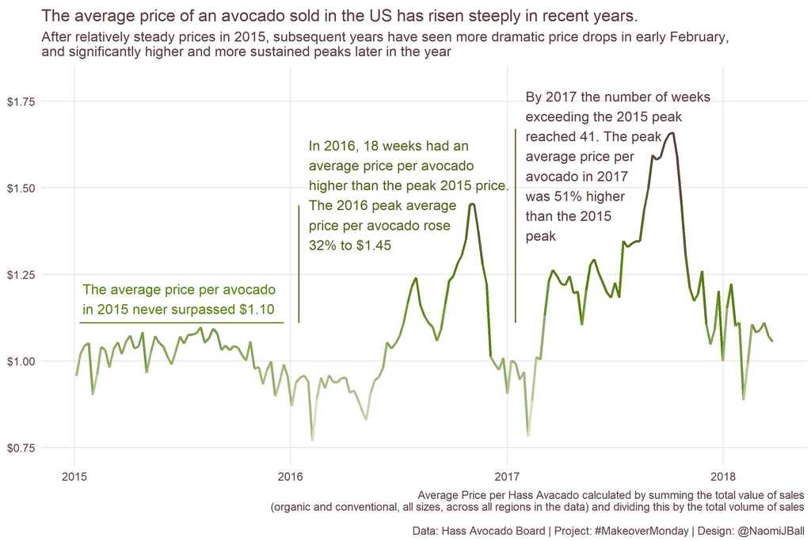

## MakeoverMonday 2018 Wk 40 - the price of avocados

Original vis: https://overridge.com/market-update/market-update-oct-17

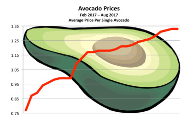

I quite liked the original graph this week - the illustration makes it memorable. However, I was interested to know whether the highlighted trend was unusual. The graph only showed one year, so it wasn’t possible to tell whether the variation was simply due to seasonal availability. That provided the first topic to explore: **was the increase in avocado price in 2017 normal?**

As usual, first step is to read in the data and carry out some simple formatting.

```r
#Load required libraries
library(ggplot2)
library(dplyr)
library(lubridate)
library(scales)

#Import 'avocado.csv'
avocados <- read.csv("../data//avocado.csv", header = TRUE, sep = ",")

#Date is factor - need to turn into character, then date
avocados$Date <- as.character(avocados$Date)

avocados$Date_dt <- as.Date(avocados$Date, format = "%d/%m/%Y" )
avocados$Date_yr <- format(avocados$Date_dt, "%Y")
avocados$Date_month <- format(avocados$Date_dt, "%m")
avocados$Date_yr_month <- format(avocados$Date_dt, "%Y-%m")
avocados$Date_month_day <- format(avocados$Date_dt, "%m-%d")
```

## Aggregating over region and type

I was interested in the overall trend, irrespective of region and type. Aggregating averages can be tricky and is sometimes impossible, but in this case we have both the average price and total volume sold. This allows us to calculate total sales value, aggregate by summing total volume and total sales value, then recalculate the average price per avocado at the aggregated level.

```r
#Filter to only include TotalUS region
avocados_us <- avocados %>%
              filter(Region == "TotalUS")

#Aggregate across conventional and organic
avocados_us$Sales <- avocados_us$Total.Volume * avocados_us$AveragePrice
# Aggregate to one row per date, summing over type
avocados_us_agg_dt <- avocados_us %>%
  group_by(Date_dt, Date_yr, Date_month, Date_yr_month, Date_month_day) %>%
  summarise(Total.Volume = sum(Total.Volume),
            Sales = sum(Sales),
            AveragePrice = Sales/Total.Volume) %>%
  ungroup()
```

## Plot the data

Start with a simple line graph.

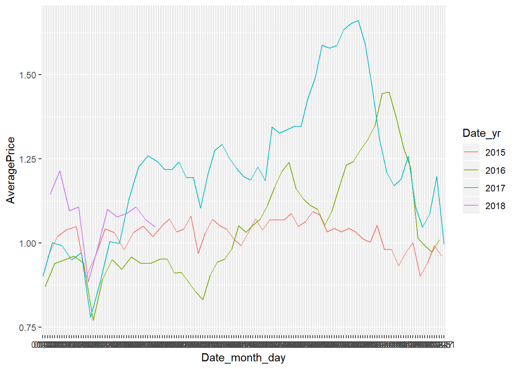

```r
#Create the base graph
ggplot(avocados_us_agg_dt, aes(x=Date_month_day, y = AveragePrice )) +
  geom_line(aes(group = Date_yr, colour = Date_yr))
```

So, there is a story there. After relatively stable prices in 2015, there were significant price hikes in 2016 and 2017. There’s also something unusual happening each February… *(I’d later learn from other #MakeoverMonday contributions that this coincides with Superbowl Sunday in the US. Perhaps stores use avocados as a loss leader to pull in guacamole-seeking football fans?)*

To answer my original question, the upwards trend may be becoming seasonal, but it also represents a significant increase from 2015 prices. When exploring the data I deliberately plotted the years on the same stretch of x axis to make seasonal patterns clearer. But once I had uncovered the story, I decided it would be more effective to show each year in its own section of the x axis, so the reader could use horizontal placement rather than colour to identify which year was which.

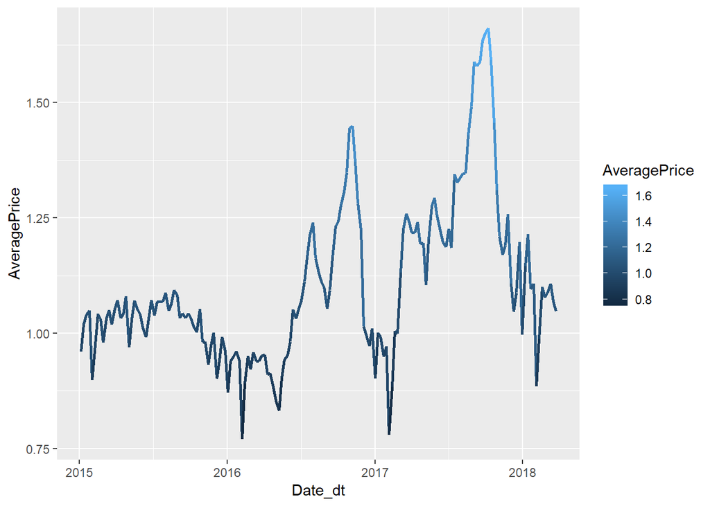

```r
(g_avo_us <-ggplot(avocados_us_agg_dt, aes(x=Date_dt, y = AveragePrice )) +
    geom_line(aes( colour = AveragePrice), size = 1) )
```

And with some formatting

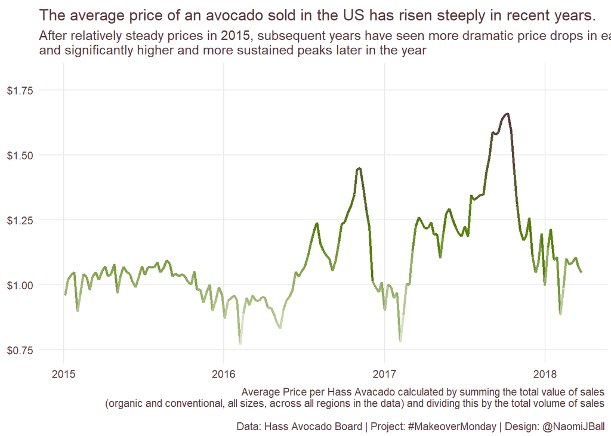

```r
(g_avo_us_fmt <- g_avo_us +
    scale_color_gradient2(high = "#583a3f", mid = "#568203", low = "#e3e9d6", midpoint = 1.2, guide = FALSE) +
    theme_minimal() +
    theme(panel.grid.minor = element_blank(),
          axis.title = element_blank(),
          text = element_text(colour = "#583a3f"),
          axis.text = element_text(colour = "#583a3f"),
          plot.margin = unit(c(0.25, 0.1, 0.1,0.2), "cm") #top, right, bottom, left
    ) +
    scale_y_continuous(breaks = seq(0.75,2,0.25), limits = c(0.75,1.8), labels = dollar)+
    labs(title = "The average price of an avocado sold in the US has risen steeply in recent years.",
         subtitle = "After relatively steady prices in 2015, subsequent years have seen more dramatic price drops in early February, \nand significantly higher and more sustained peaks later in the year",
         caption = "Average Price per Hass Avacado calculated by summing the total value of sales \n(organic and conventional, all sizes, across all regions in the data) and dividing this by the total volume of sales \n \nData: Hass Avocado Board | Project: #MakeoverMonday | Design: @NaomiJBall " )
)
```

Finally, we add the annotation

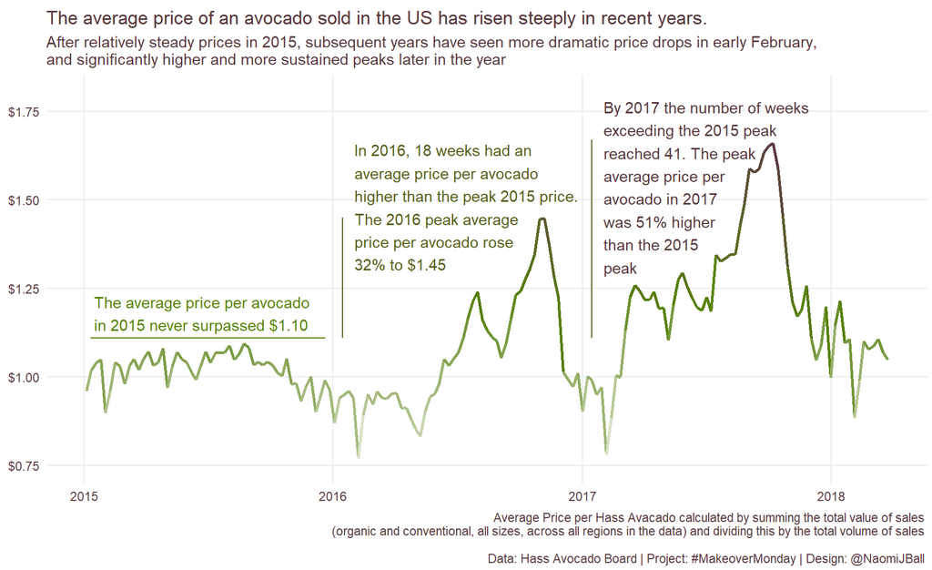

```r
#Add annotation
(g_avo_annot <- g_avo_us_fmt +
   geom_segment(aes(x = as.Date("2015-01-10"), xend =as.Date("2015-12-21"), y = 1.11, yend = 1.11 ), colour = "#568203") +
  geom_segment(aes(x = as.Date("2016-01-15"), xend =as.Date("2016-01-15"), y = 1.11, yend = 1.45 ), colour = "#57601a") +
  geom_segment(aes(x = as.Date("2017-01-15"), xend =as.Date("2017-01-15"), y = 1.11, yend = 1.67 ), colour = "#57601a") +
  #geom_segment(aes(x = as.Date("2017-01-10"), xend =as.Date("2017-10-01"), y = 1.67, yend = 1.67 ), colour = "#568203") +
  annotate("text", x = as.Date("2015-01-15"), y = 1.18,
                label = "The average price per avocado \nin 2015 never surpassed $1.10",
                hjust = 0, colour = "#568203") +
  annotate("text", x = as.Date("2016-02-01"), y = 1.48,
                label = "In 2016, 18 weeks had an \naverage price per avocado \nhigher than the peak 2015 price. \nThe 2016 peak average \nprice per avocado rose \n32% to $1.45 ",
                hjust = 0, vjust = 0.5, colour = "#57601a") +
  annotate("text", x = as.Date("2017-02-01"), y = 1.78,
         label = "By 2017 the number of weeks \nexceeding the 2015 peak \nreached 41. The peak \naverage price per \navocado in 2017 \nwas 51% higher \nthan the 2015 \npeak" ,
         hjust = 0, vjust = 1, colour = "#583a3f")
)
```

So, yes, avocados are getting more expensive, but look out for those February bargains!